# **Machine Learning for Sentiment Analysis in Customers Feedback**

### CSC 572 - Introduction to Machine Learning

### Group 2 Project

### Kayode, Peter Temitope - 208077

### Nwatu, Chidinma - 214890

### Michael Oluwayemi Olatunji - 214903

### Alatise, Oluwaseun - 214860

### Ogbolu, Precious - 214894

### Alao, Tawakalit - 222461

### Olagidi, Joshua - 222500

### Daniel, Oghie - 214895

### Ikwuegbu, Michael - 214881

### Akinade, Faith Eniola -222459

### Oyekanmi, Eniola - 214913

### Ahunanya, Uchechukwu - 214854

### **Outline**

#### 1. Libraries and Modules Importing

#### 2. Data Exploration and Visualization

#### 3. Data Preprocessing

#### 4. Model Training

#### 5. Model Evaluation

#### 6. Model Comparison

## **1. Libraries and Modules Importing**

```python
import pandas as pd
import numpy as np
import re
import string
import matplotlib.pyplot as plt
import seaborn as sns
import pickle
from wordcloud import WordCloud
from sklearn.model_selection import train_test_split
from sklearn.feature_extraction.text import TfidfVectorizer
from sklearn.naive_bayes import MultinomialNB
from sklearn.svm import SVC
from sklearn.ensemble import RandomForestClassifier
from sklearn.metrics import accuracy_score, classification_report, confusion_matrix, f1_score, confusion_matrix
import nltk
from nltk.corpus import stopwords
from nltk.tokenize import word_tokenize
from nltk.stem import WordNetLemmatizer
from textblob import TextBlob
import os
import emoji
```

##### 1. Data Handling and Manipulation

```
import pandas as pd
import numpy as np
```

- **pandas (pd)**: Used for handling and manipulating structured datasets, particularly **CSV files** and **DataFrames**.
- **numpy (np)**: Provides support for numerical operations, arrays, and matrices.

##### 2. Regular Expressions and String Processing

```
import re
import string
```

- **re (Regular Expressions)**: Used for text processing tasks such as **removing special characters, finding patterns**, and **text cleaning**.
- **string**: Provides a set of string-related utilities (e.g., `string.punctuation` helps in removing punctuation marks).

##### 3. Data Visualization

```
import matplotlib.pyplot as plt
import seaborn as sns
from wordcloud import WordCloud
```

- **matplotlib.pyplot (plt)**: A powerful plotting library for creating **static, animated, and interactive visualizations**.
- **seaborn (sns)**: Built on top of Matplotlib, **Seaborn provides advanced data visualization** features, especially for statistical graphics.
- **WordCloud**: Helps in generating **word clouds**, useful for NLP applications.

##### 4. Machine Learning and NLP Feature Engineering

```
from sklearn.model_selection import train_test_split
from sklearn.feature_extraction.text import TfidfVectorizer
```

- **train_test_split**: Splits the dataset into **training and testing sets**.
- **TfidfVectorizer**: Converts text data into **TF-IDF features**, which measure word importance in a document.

##### 5. Machine Learning Models

```
from sklearn.naive_bayes import MultinomialNB
from sklearn.svm import SVC
from sklearn.ensemble import RandomForestClassifier
```

- **MultinomialNB**: A **Naïve Bayes classifier**, commonly used for **text classification**.
- **SVC (Support Vector Classifier)**: A powerful **classification algorithm** used for various machine learning tasks.
- **RandomForestClassifier**: An **ensemble learning model** that combines multiple decision trees for better accuracy.

##### 6. Model Evaluation Metrics

```
from sklearn.metrics import accuracy_score, classification_report, confusion_matrix, f1_score
```

- **accuracy_score**: Measures **the percentage of correctly predicted labels**.
- **classification_report**: Provides a **detailed summary of precision, recall, and F1-score**.
- **confusion_matrix**: Shows **true positives, false positives, true negatives, and false negatives**.
- **f1_score**: A metric that balances **precision and recall**, useful for imbalanced datasets.

##### 7. Natural Language Processing (NLP)

```
import nltk
from nltk.corpus import stopwords
from nltk.tokenize import word_tokenize
from nltk.stem import WordNetLemmatizer
```

- **nltk (Natural Language Toolkit)**: A powerful library for **processing human language data**.
- **stopwords**: Provides a list of common words (e.g., "the", "is", "and") that do not add meaning.
- **word_tokenize**: Splits text into **individual words or tokens**.
- **WordNetLemmatizer**: Reduces words to their **base or root form** (e.g., "running" → "run").

##### 8. Sentiment Analysis

```
from textblob import TextBlob
```

- **TextBlob**: A simple NLP library for **sentiment analysis, text classification, and spelling correction**.

##### 9. File Handling and Object Serialization

```
import os
import pickle
```

- **os**: Handles **file operations** like reading/writing directories and managing file paths.
- **pickle**: Used to **save and load Python objects** (e.g., trained machine learning models) for later use.

##### 10. Emoji Processing

```
import emoji
```

- **emoji**: Helps process and convert **emojis into text representations**, which is useful in **sentiment analysis and social media data processing**.

```python
# Load and Merge Multiple CSV Files
def load_and_merge_data(folder_path):
    all_files = [os.path.join(folder_path, f) for f in os.listdir(folder_path) if f.endswith('.csv')]
    df_list = [pd.read_csv(file) for file in all_files]
    return pd.concat(df_list, ignore_index=True)
```

#### Load and Merge Multiple CSV Files

```
def load_and_merge_data(folder_path):
    """
    Loads and merges multiple CSV files from the specified folder into a single DataFrame.

    Parameters:
    folder_path (str): The path to the folder containing CSV files.

    Returns:
    pd.DataFrame: A concatenated DataFrame containing data from all CSV files.
    """
```

## **2. Data Exploration and Visualization**

```python
# Load dataset from folder
data = load_and_merge_data("C:/Users/HP/Documents/Sentiment_Analysis_ML_Project/data")
```

```python
# Drop unnecessary columns (Except the content and the score column)
data = data[['content', 'score']]
```

The above code drops all unneccessary columns except the `content` column, which contains customers feedback, and the `score` columns which also contains their respective ratings between 1-5. 1, being the lowest rating/score, indicating the lowest from of satisfaction. 5, being the highest rating/score, indicating maximum satisfaction.

```python
# Check for missing values
print("Missing Values in the Dataset:")
print(data.isnull().sum())

# General Overview of Data
print("\nDataset Overview:")
print(data.describe())
```

```
Missing Values in the Dataset:
content    10
score       0
dtype: int64

Dataset Overview:
               score
count  170000.000000
mean        3.897700
std         1.615204
min         1.000000
25%         3.000000
50%         5.000000
75%         5.000000
max         5.000000
```

Indicates that the content column contains 10 missing values

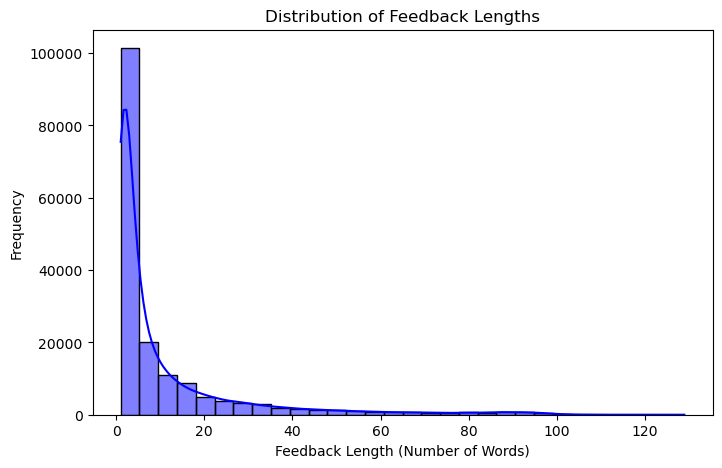

```python
# Check the distribution of feedback lengths
data['feedback_length'] = data['content'].apply(lambda x: len(str(x).split()))
plt.figure(figsize=(8, 5))
sns.histplot(data['feedback_length'], kde=True, color='blue', bins=30)
plt.title("Distribution of Feedback Lengths")
plt.xlabel("Feedback Length (Number of Words)")
plt.ylabel("Frequency")
plt.show()
```

### Check the Distribution of Feedback Lengths

This section analyzes the distribution of feedback lengths within the dataset.

- **Creating a New Column**: The code extracts the number of words in each feedback entry by splitting the text and counting the words:

  ```
  data['feedback_length'] = data['content'].apply(lambda x: len(str(x).split()))
  ```

- **Visualization**: A histogram with Kernel Density Estimation (KDE) is used to show the distribution of feedback lengths:

  ```
  sns.histplot(data['feedback_length'], kde=True, color='blue', bins=30)
  ```

- **Figure Customization**: The plot size is set to `(8,5)` to improve readability:

  ```
  plt.figure(figsize=(8, 5))
  ```

- **Labeling**: The title and axis labels enhance clarity:

  ```
  plt.title("Distribution of Feedback Lengths")
  plt.xlabel("Feedback Length (Number of Words)")
  plt.ylabel("Frequency")
  ```

- **Interpretation**: This visualization helps in understanding the typical length of feedback, which can be useful for preprocessing and feature engineering in NLP tasks.

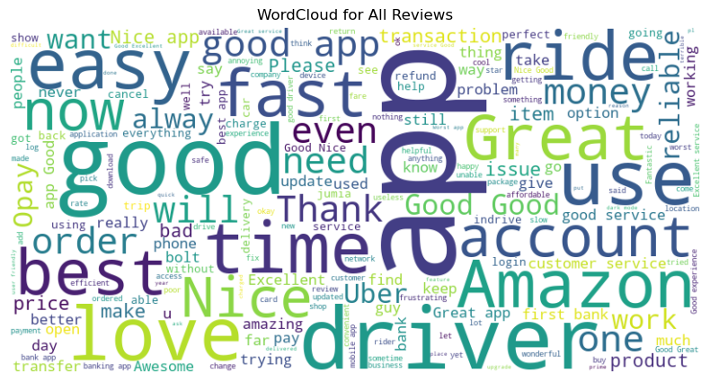

```python
# Ensure all values are strings, handling NaN or non-string entries
data['content'] = data['content'].fillna('')  # Replace NaN with empty string
data['content'] = data['content'].astype(str)  # Convert all values to string

# WordCloud for All Reviews
all_reviews_text = ' '.join(data['content'])
wordcloud_all = WordCloud(width=800, height=400, background_color='white').generate(all_reviews_text)
plt.figure(figsize=(10, 5))
plt.imshow(wordcloud_all, interpolation='bilinear')
plt.axis("off")
plt.title("WordCloud for All Reviews")
plt.show()
```

### Ensuring Consistency in Text Data

This section ensures that all values in the `content` column are properly formatted as strings and that missing values are handled.

- **Handling Missing Values**: NaN values are replaced with empty strings to prevent errors during text processing:

  ```
  data['content'] = data['content'].fillna('')
  ```

- **Ensuring String Data Type**: All entries in the `content` column are explicitly converted to strings:

  ```
  data['content'] = data['content'].astype(str)
  ```

### Generating a Word Cloud for All Reviews

A word cloud visually represents the most frequently occurring words in the dataset.

- **Concatenating All Reviews**: The text data is merged into a single string:

  ```
  all_reviews_text = ' '.join(data['content'])
  ```

- **Creating the Word Cloud**: The `WordCloud` library is used to generate the visualization:

  ```
  wordcloud_all = WordCloud(width=800, height=400, background_color='white').generate(all_reviews_text)
  ```

- **Displaying the Word Cloud**:

  ```
  plt.figure(figsize=(10, 5))
  plt.imshow(wordcloud_all, interpolation='bilinear')
  plt.axis("off")
  plt.title("WordCloud for All Reviews")
  plt.show()
  ```

- **Interpretation**: The word cloud helps identify common words in the reviews, giving insight into key themes and frequently discussed topics.

```python
data
```

|  | content | score | feedback_length |
| --- | --- | --- | --- |
| 0 | First time | 3 | 2 |
| 1 | One of the best app in the world | 5 | 8 |
| 2 | Pharmaces | 5 | 1 |
| 3 | V good | 5 | 2 |
| 4 | Great | 3 | 1 |
| ... | ... | ... | ... |
| 169995 | Drivers accept a booking and then cancel it an... | 1 | 34 |
| 169996 | Problem persists. 😡 The app keeps sending the ... | 2 | 94 |
| 169997 | Let's not show ads to uber one members. | 1 | 8 |
| 169998 | O aplicativo me obriga a avaliar a corrida ant... | 1 | 14 |
| 169999 | Nice seevice | 5 | 2 |

170000 rows × 3 columns

```python
# Convert Rating to Sentiment Labels
def label_sentiment(rating):
    if rating >= 4:
        return 1  # Positive
    elif rating == 3:
        return 2  # Neutral
    else:
        return 0  # Negative

data.loc[:, 'sentiment'] = data['score'].apply(label_sentiment)
```

### Converting Ratings to Sentiment Labels

This section assigns sentiment labels to reviews based on their ratings.

- **Function Definition**: The function `label_sentiment()` maps numerical ratings to sentiment categories:

  ```
  def label_sentiment(rating):
      if rating >= 4:
          return 1  # Positive
      elif rating == 3:
          return 2  # Neutral
      else:
          return 0  # Negative
  ```

- **Applying the Function**: The sentiment labels are assigned using the `apply()` method:

  ```
  data.loc[:, 'sentiment'] = data['score'].apply(label_sentiment)
  ```

- **Interpretation**:
  - Ratings **4 and above** are classified as **Positive (1)**.
  - A rating of **3** is considered **Neutral (2)**.
  - Ratings **below 3** are categorized as **Negative (0)**.
  - This transformation helps in building models, since it requires categorical labels for sentiment analysis.

```python
data
```

|  | content | score | feedback_length | sentiment |
| --- | --- | --- | --- | --- |
| 0 | First time | 3 | 2 | 2 |
| 1 | One of the best app in the world | 5 | 8 | 1 |
| 2 | Pharmaces | 5 | 1 | 1 |
| 3 | V good | 5 | 2 | 1 |
| 4 | Great | 3 | 1 | 2 |
| ... | ... | ... | ... | ... |
| 169995 | Drivers accept a booking and then cancel it an... | 1 | 34 | 0 |
| 169996 | Problem persists. 😡 The app keeps sending the ... | 2 | 94 | 0 |
| 169997 | Let's not show ads to uber one members. | 1 | 8 | 0 |
| 169998 | O aplicativo me obriga a avaliar a corrida ant... | 1 | 14 | 0 |
| 169999 | Nice seevice | 5 | 2 | 1 |

170000 rows × 4 columns

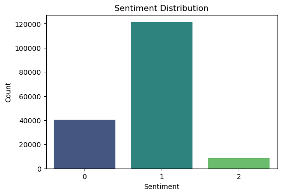

```python
# Sentiment Distribution Plot
plt.figure(figsize=(6, 4))
sns.countplot(x=data['sentiment'], palette='viridis')
plt.title("Sentiment Distribution")
plt.xlabel("Sentiment")
plt.ylabel("Count")
plt.show()
```

#### Sentiment Distribution Plot

The code visualizes the distribution of sentiment labels assigned to the reviews.

- **Plot Type**: A count plot is used to show the number of occurrences of each sentiment label:

  ```
  sns.countplot(x=data['sentiment'], palette='viridis')
  ```

- **Figure Customization**: The figure size is set for better readability:

  ```
  plt.figure(figsize=(6, 4))
  ```

- **Labeling**: Title and axis labels enhance clarity:

  ```
  plt.title("Sentiment Distribution")
  plt.xlabel("Sentiment")
  plt.ylabel("Count")
  ```

- **Interpretation**: This visualization provides insight into the distribution of sentiments in the dataset, helping to assess data balance and model training needs.

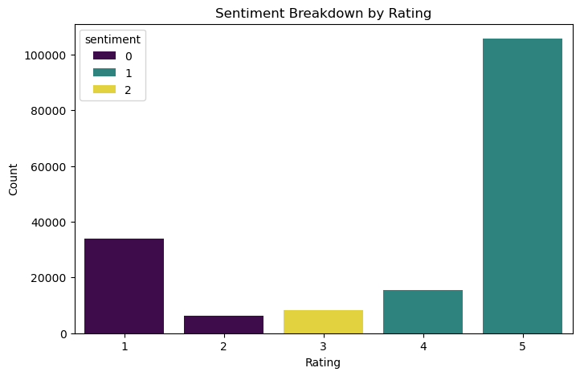

```python
# Sentiment Breakdown by Rating
plt.figure(figsize=(8, 5))
sns.countplot(x=data['score'], hue=data['sentiment'], palette='viridis')
plt.title("Sentiment Breakdown by Rating")
plt.xlabel("Rating")
plt.ylabel("Count")
plt.show()
```

## **3. Data Preprocessing**

```python
# Data Preprocessing

def remove_emojis(text):
    return emoji.replace_emoji(text, replace='')  # Removes emojis

def preprocess_text(text):
    text = str(text).lower()
    text = remove_emojis(text)  # Remove emojis
    text = re.sub(r'http\S+|www\S+', '', text)  # Remove URLs
    text = text.translate(str.maketrans('', '', string.punctuation))  # Remove punctuation
    tokens = word_tokenize(text)  # Tokenize
    tokens = [word for word in tokens if word not in stopwords.words('english')]  # Remove stopwords
    lemmatizer = WordNetLemmatizer()
    tokens = [lemmatizer.lemmatize(word) for word in tokens]  # Lemmatization
    return ' '.join(tokens)

data.loc[:, 'cleaned_feedback'] = data['content'].apply(preprocess_text)
data.to_csv("clean_data.csv", index=False, encoding="utf-8")
```

### Data Preprocessing

- **Removing Emojis**: Since emojis can introduce noise in text analysis, they are removed:

  ```
  def remove_emojis(text):
      return emoji.replace_emoji(text, replace='')
  ```

- **Text Preprocessing**: The function `preprocess_text()` performs the following:
  1. Converts text to lowercase.
  2. Removes emojis.
  3. Removes URLs.
  4. Eliminates punctuation.
  5. Tokenizes text into words.
  6. Removes stopwords (common words that do not add meaning).
  7. Applies lemmatization (converts words to their base form).
- **Applying Preprocessing**:

  ```
  data.loc[:, 'cleaned_feedback'] = data['content'].apply(preprocess_text)
  ```

- **Saving Cleaned Data**:

  ```
  data.to_csv("clean_data.csv", index=False, encoding="utf-8")
  ```

Preprocessing improves model accuracy by removing irrelevant or noisy elements and ensuring text uniformity for machine learning models.

```python
data
```

|  | content | score | feedback_length | sentiment | cleaned_feedback |
| --- | --- | --- | --- | --- | --- |
| 0 | First time | 3 | 2 | 2 | first time |
| 1 | One of the best app in the world | 5 | 8 | 1 | one best app world |
| 2 | Pharmaces | 5 | 1 | 1 | pharmaces |
| 3 | V good | 5 | 2 | 1 | v good |
| 4 | Great | 3 | 1 | 2 | great |
| ... | ... | ... | ... | ... | ... |
| 169995 | Drivers accept a booking and then cancel it an... | 1 | 34 | 0 | driver accept booking cancel get 1 rarely get ... |
| 169996 | Problem persists. 😡 The app keeps sending the ... | 2 | 94 | 0 | problem persists app keep sending driver wrong... |
| 169997 | Let's not show ads to uber one members. | 1 | 8 | 0 | let show ad uber one member |
| 169998 | O aplicativo me obriga a avaliar a corrida ant... | 1 | 14 | 0 | aplicativo obriga avaliar corrida anterior ant... |
| 169999 | Nice seevice | 5 | 2 | 1 | nice seevice |

170000 rows × 5 columns

```python
# Sentiment Analysis with TextBlob
def analyze_sentiment(text):
    analysis = TextBlob(text)
    return analysis.sentiment.polarity, analysis.sentiment.subjectivity

data.loc[:, ['polarity', 'subjectivity']] = data['cleaned_feedback'].apply(lambda x: pd.Series(analyze_sentiment(x)))
```

### Sentiment Analysis with TextBlob

The above code uses the TextBlob library to analyze sentiment polarity and subjectivity.

- **Function Definition**: The function `analyze_sentiment()` computes sentiment polarity and subjectivity for a given text:

  ```
  def analyze_sentiment(text):
      analysis = TextBlob(text)
      return analysis.sentiment.polarity, analysis.sentiment.subjectivity
  ```

- **Applying the Function**: The function is applied to each cleaned review, storing the results in two new columns:

  ```
  data.loc[:, ['polarity', 'subjectivity']] = data['cleaned_feedback'].apply(lambda x: pd.Series(analyze_sentiment(x)))
  ```

- **Interpretation**:
  - **Polarity** ranges from -1 (negative) to 1 (positive), indicating the sentiment strength.
  - **Subjectivity** ranges from 0 (objective) to 1 (subjective), measuring personal opinion versus factual content.
  - This analysis provides a numerical representation of sentiment, useful for further classification or visualization.

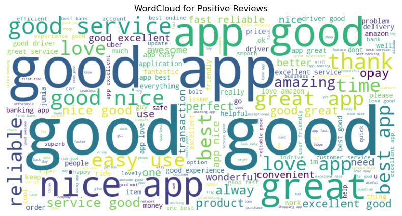

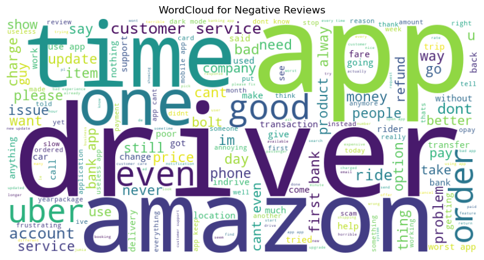

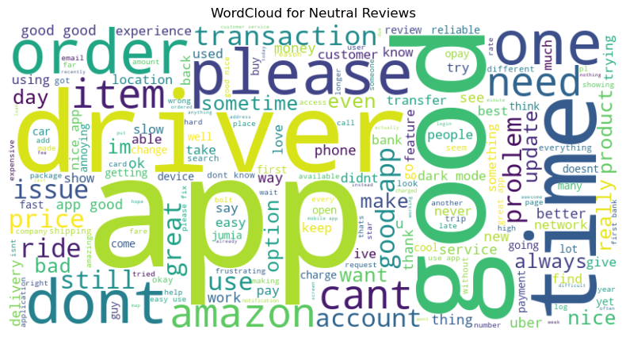

```python
# WordCloud for Sentiments
for sentiment, title in zip([1, 0, 2], ["Positive", "Negative", "Neutral"]):
    sentiment_text = ' '.join(data[data['sentiment'] == sentiment]['cleaned_feedback'])
    wordcloud = WordCloud(width=800, height=400, background_color='white').generate(sentiment_text)
    plt.figure(figsize=(10, 5))
    plt.imshow(wordcloud, interpolation='bilinear')
    plt.axis("off")
    plt.title(f"WordCloud for {title} Reviews")
    plt.show()
```

The above code generates word clouds for three different sentiment categories: Positive, Negative, and Neutral. The word clouds visually represent the most frequent words in the feedback associated with each sentiment type.

##### 1. **Iterating Over Sentiments:**

The code uses a `zip` function to iterate over three different sentiment values (1, 0, 2) and their corresponding titles ("Positive", "Negative", "Neutral").

- **1** represents Positive sentiment.
- **0** represents Negative sentiment.
- **2** represents Neutral sentiment.

For each iteration:

- **Sentiment value** and **title** (Positive, Negative, Neutral) are extracted.

##### 2. **Extracting the Feedback:**

- `sentiment_text` is created by joining together all feedback text (`cleaned_feedback`) for the given sentiment. The feedback is filtered based on the sentiment using `data[data['sentiment'] == sentiment]`.
- `data['sentiment']` is a column that contains the sentiment labels for each feedback.

##### 3. **Generating the WordCloud:**

- The `WordCloud` class from the `wordcloud` library is used to generate a word cloud image. The width and height are set to `800` and `400`, respectively, and the background color is set to white.
- `generate(sentiment_text)` generates the word cloud based on the feedback text.

Each word cloud shows the most frequently used words in the feedback for that sentiment type.

```python
# Feature Extraction (TF-IDF)
vectorizer = TfidfVectorizer()
X = vectorizer.fit_transform(data['cleaned_feedback'])
y = data['sentiment']
```

The code performs feature extraction on the `cleaned_feedback` column in the dataset using the **TF-IDF (Term Frequency-Inverse Document Frequency)** technique. TF-IDF is commonly used to convert text data into numerical features that can be fed into machine learning models for tasks like classification.

##### 1. **Initializing the TF-IDF Vectorizer:**

- `vectorizer = TfidfVectorizer()`: This line initializes the **TfidfVectorizer** from the `sklearn.feature_extraction.text` module. The `TfidfVectorizer` is responsible for converting the text data into numerical features based on the TF-IDF algorithm.
- **TF-IDF Formula:**
  - **Term Frequency (TF)**: Measures the frequency of a word in a document.
  - **Inverse Document Frequency (IDF)**: Measures the importance of the word across all documents (feedback, in this case).
  - The product of these two values determines the weight of each word in the document.

##### 2. **Fitting the Vectorizer:**

- `X = vectorizer.fit_transform(data['cleaned_feedback'])`:
  - **`data['cleaned_feedback']`**: The input data, which is a column containing the cleaned textual feedback from the dataset.
  - **`fit_transform()`**: This method fits the vectorizer to the data (learns the vocabulary) and transforms the `cleaned_feedback` into a sparse matrix representation, where each row represents a feedback document and each column represents a term from the vocabulary. The value at each position indicates the TF-IDF score of the word in the respective feedback.
- The resulting `X` is a **sparse matrix** of shape `(n_samples, n_features)`, where:
  - **n_samples**: Number of feedback samples (documents).
  - **n_features**: Number of unique terms (words) extracted from the `cleaned_feedback` column.

##### 3. **Defining the Target Labels (Sentiment):**

- `y = data['sentiment']`: This line assigns the sentiment labels (target variable) to the variable `y`. The sentiment column in the dataset typically contains values representing different sentiment categories (positive, negative, neutral).
- `y` will be used as the target variable for training machine learning models.

##### Purpose of TF-IDF:

The TF-IDF technique is important because it:

- **Weights words based on their importance**: Words that appear frequently in a specific document but rarely across all documents will have higher weights, making them more significant.
- **Removes common words**: Common words like "the," "is," etc., are typically down-weighted because they do not provide meaningful information.

## **4. Model Training**

```python
# Train-Test Split
X_train, X_test, y_train, y_test = train_test_split(X, y, test_size=0.2, random_state=42)
```

The above code performs a train-test split on the feature matrix `X` and the target variable `y` using the **train_test_split** function from the `sklearn.model_selection` module. The purpose of this step is to prepare the data for training and evaluation of machine learning models by splitting it into training and testing sets.

##### **Performing the Split:**

- `X_train, X_test, y_train, y_test = train_test_split(X, y, test_size=0.2, random_state=42)`:
  - **`X`**: This is the feature matrix containing the TF-IDF transformed text data (the cleaned feedback in the form of numerical values).
  - **`y`**: This is the target variable, which contains the sentiment labels (positive, negative, neutral).

  The `train_test_split` function divides the dataset into:
  - **Training Set**: Used for training the model (80% of the data).
  - **Test Set**: Used for evaluating the performance of the trained model (20% of the data).
- **Parameters:**
  - `test_size=0.2`: Specifies that 20% of the data should be used for testing and the remaining 80% will be used for training. You can adjust this value to allocate a different proportion of data to training and testing.
  - `random_state=42`: This is a seed value used to ensure reproducibility of the split. By setting the `random_state`, the split will be the same every time the code is run, making the results consistent and comparable.

##### **Output Variables:**

- `X_train`: Contains the training feature matrix (80% of `X`).
- `X_test`: Contains the testing feature matrix (20% of `X`).
- `y_train`: Contains the training target labels (80% of `y`).
- `y_test`: Contains the testing target labels (20% of `y`).

##### **Purpose of the Train-Test Split:**

- **Training Set (`X_train`, `y_train`)**: This subset of the data is used to train the machine learning model. The model will learn patterns in the data to make predictions.
- **Test Set (`X_test`, `y_test`)**: This subset of the data is used to evaluate how well the trained model generalizes to unseen data. It helps in assessing the model's performance and detecting issues like overfitting.

```python
# Model Training and Saving
models = {
    'Naive Bayes': MultinomialNB(),
    'SVM': SVC(kernel='linear', probability=True),
    'Random Forest': RandomForestClassifier(n_estimators=100)
}
```

The above code defines and initializes three different machine learning models, which are then ready for training on the dataset. The models selected are:

- **Naive Bayes**
- **Support Vector Machine (SVM)**
- **Random Forest**

Each model will be trained using the training data, and their performance can be compared later.

#### **Creating a Dictionary of Models:**

- The code uses a Python dictionary to store the different machine learning models and their respective names for easy reference. This allows you to train multiple models in a loop or comparison easily.

```
models = {
    'Naive Bayes': MultinomialNB(),
    'SVM': SVC(kernel='linear', probability=True),
    'Random Forest': RandomForestClassifier(n_estimators=100)
}
```

#### **Naive Bayes (MultinomialNB)**

`MultinomialNB()` is an implementation of the Naive Bayes classifier, which is particularly well-suited for classification tasks where the features are categorical or based on counts, such as word counts in text data. It works by applying Bayes’ theorem with the assumption that the features are independent.

#### **Support Vector Machine (SVM)**

`SVC(kernel='linear', probability=True)` initializes a Support Vector Classifier (SVC) with a linear kernel, which is a common choice for text classification tasks. The `probability=True` argument enables the model to output probabilities for the predictions, which can be useful for tasks like probabilistic classification.

#### **Random Forest**

`RandomForestClassifier(n_estimators=100)` initializes a Random Forest Classifier, an ensemble learning model that builds multiple decision trees and combines their predictions to make a final decision. The `n_estimators=100` parameter specifies that the random forest should consist of 100 trees.

## **5. Model Evaluation**

```
Naive Bayes Model Evaluation:
              precision    recall  f1-score   support

           0       0.78      0.78      0.78      7994
           1       0.90      0.95      0.92     24350
           2       0.05      0.00      0.00      1656

    accuracy                           0.87     34000
   macro avg       0.58      0.58      0.57     34000
weighted avg       0.83      0.87      0.85     34000
```

[figure not shown]

```
--------------------------------------------------
SVM Model Evaluation:
              precision    recall  f1-score   support

           0       0.79      0.78      0.78      7994
           1       0.89      0.96      0.92     24350
           2       0.60      0.00      0.00      1656

    accuracy                           0.87     34000
   macro avg       0.76      0.58      0.57     34000
weighted avg       0.85      0.87      0.85     34000
```

[figure not shown]

```
--------------------------------------------------
Random Forest Model Evaluation:
              precision    recall  f1-score   support

           0       0.77      0.80      0.78      7994
           1       0.90      0.95      0.92     24350
           2       0.19      0.01      0.02      1656

    accuracy                           0.87     34000
   macro avg       0.62      0.58      0.57     34000
weighted avg       0.83      0.87      0.85     34000
```

[figure not shown]

```python
model_performance = {}
for name, model in models.items():
    model.fit(X_train, y_train)
    pickle.dump(model, open(f"{name.replace(' ', '_').lower()}_model.pkl", 'wb'))
    y_pred = model.predict(X_test)
    accuracy = accuracy_score(y_test, y_pred)
    f1 = f1_score(y_test, y_pred, average='weighted')
    model_performance[name] = {'Accuracy': accuracy, 'F1 Score': f1}

    print(f"{name} Model Evaluation:")
    print(classification_report(y_test, y_pred))

    # Confusion Matrix Visualization
    cm = confusion_matrix(y_test, y_pred)
    plt.figure(figsize=(8, 6))
    sns.heatmap(cm, annot=True, fmt="d", cmap='Blues', xticklabels=["Negative", "Neutral", "Positive"], yticklabels=["Negative", "Neutral", "Positive"])
    plt.title(f"Confusion Matrix - {name}")
    plt.xlabel("Predicted")
    plt.ylabel("True")
    plt.show()

    print("-"*50)
```

The above code performs the evaluation of the trained models (Naive Bayes, SVM, and Random Forest) and saves them using `pickle`. It also calculates and displays key performance metrics such as **Accuracy**, **F1 Score**, and the **Confusion Matrix** for each model.

##### 1. **Initializing Model Performance Dictionary:**

- A dictionary called `model_performance` is created to store the performance metrics (Accuracy and F1 Score) of each model for easy comparison.

```
model_performance = {}
```

##### 2. **Training Models and Evaluating Performance:**

- The loop iterates over each model stored in the `models` dictionary. For each model:
  1. The model is trained on the training data (`X_train`, `y_train`).
  2. The trained model is saved to a file using `pickle.dump()`.
  3. Predictions (`y_pred`) are made on the test data (`X_test`).
  4. The **Accuracy** and **F1 Score** of the model are calculated using `accuracy_score` and `f1_score`.
  5. The results are stored in the `model_performance` dictionary.

```
for name, model in models.items():
    model.fit(X_train, y_train)
    pickle.dump(model, open(f"{name.replace(' ', '_').lower()}_model.pkl", 'wb'))
    y_pred = model.predict(X_test)
    accuracy = accuracy_score(y_test, y_pred)
    f1 = f1_score(y_test, y_pred, average='weighted')
    model_performance[name] = {'Accuracy': accuracy, 'F1 Score': f1}
```

**Explanation:**

- **Training**: Each model is trained using the `fit()` method with the training data.
- **Saving**: The model is saved using `pickle.dump()` to allow future use without retraining.
- **Prediction**: The `predict()` method is used to generate predictions for the test data (`X_test`).
- **Accuracy & F1 Score**: These metrics help evaluate how well the model performs on the test data.

##### 3. **Displaying Model Evaluation:**

```
print(f"{name} Model Evaluation:")
print(classification_report(y_test, y_pred))
```

**Explanation:**

- **Classification Report**: Displays a summary of the precision, recall, and F1 scores for each class in the classification task.

##### 4. **Confusion Matrix Visualization:**

- A confusion matrix is generated using `confusion_matrix()` to visualize the performance of the model in terms of True Positives, False Positives, True Negatives, and False Negatives.
- A heatmap of the confusion matrix is plotted using `seaborn.heatmap()` for easy visualization.

```
cm = confusion_matrix(y_test, y_pred)
plt.figure(figsize=(8, 6))
sns.heatmap(cm, annot=True, fmt="d", cmap='Blues', xticklabels=["Negative", "Neutral", "Positive"], yticklabels=["Negative", "Neutral", "Positive"])
plt.title(f"Confusion Matrix - {name}")
plt.xlabel("Predicted")
plt.ylabel("True")
plt.show()
```

**Explanation:**

- **Confusion Matrix**: The confusion matrix shows how many instances of each class were correctly or incorrectly predicted.
- **Heatmap**: The heatmap visualizes the confusion matrix, making it easier to spot the performance across classes.

##### 5. **Model Performance Storage:**

- The `model_performance` dictionary now stores the **Accuracy** and **F1 Score** of each model, which can later be used for comparison or reporting.

```
model_performance[name] = {'Accuracy': accuracy, 'F1 Score': f1}
```

##### 6. **Results Output:**

- After each model's evaluation, the following information is displayed:
  - **Model Evaluation**: The classification report with precision, recall, and F1 score.
  - **Confusion Matrix Visualization**: A heatmap showing the performance of the model across all classes.
  - **Separator Line**: A separator line (`"-" * 50`) is printed to visually separate the results for different models.

#### Key Metrics Explained:

- **Accuracy**: This is the proportion of correct predictions (both positive and negative) out of all predictions made.
- **F1 Score**: The F1 score is the weighted average of Precision and Recall. It is a good measure for imbalanced datasets as it considers both false positives and false negatives.
- **Confusion Matrix**: A matrix that describes the performance of a classification model by comparing the actual values with the predicted ones. It helps identify whether the model is confusing different classes.

```python
# Save TF-IDF Vectorizer
pickle.dump(vectorizer, open("tfidf_vectorizer.pkl", 'wb'))
```

The vectorizer was saved so that vectorization would not be occuring each time the code is run. Instead, it will retrieved from the pickle file for easy testing

## **6. Models Comparison**

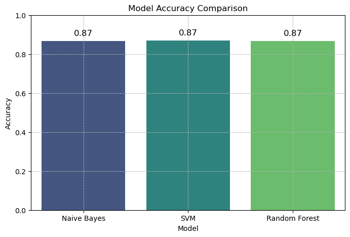

```
Naive Bayes Accuracy: 0.87
Naive Bayes F1 Score: 0.85
--------------------------------------------------
SVM Accuracy: 0.87
SVM F1 Score: 0.85
--------------------------------------------------
Random Forest Accuracy: 0.87
Random Forest F1 Score: 0.85
--------------------------------------------------
```

```python
# Model Comparison
performance_df = pd.DataFrame(model_performance).T

# Plot the Bar Plot with Grid Lines
plt.figure(figsize=(8, 5))
sns.barplot(x=performance_df.index, y=performance_df['Accuracy'], palette='viridis')

# Add Grid Lines and Exact Values
plt.title("Model Accuracy Comparison")
plt.xlabel("Model")
plt.ylabel("Accuracy")
plt.ylim(0, 1)
plt.grid(True, linestyle='--', linewidth=0.7)  # Add grid lines

# Display the accuracy values on top of each bar
for i, v in enumerate(performance_df['Accuracy']):
    plt.text(i, v + 0.02, f'{v:.2f}', ha='center', va='bottom', fontsize=12, color='black')

plt.show()

# Print the model performance explicitly for the tree model
for name, metrics in model_performance.items():
    print(f"{name} Accuracy: {metrics['Accuracy']:.2f}")
    print(f"{name} F1 Score: {metrics['F1 Score']:.2f}")
    print("-" * 50)
```

The code compares the performance of the trained models (Naive Bayes, SVM, and Random Forest) by visualizing their **Accuracy** values and displaying the results explicitly for each model.

##### 1. **Model Performance Dataframe:**

- A DataFrame `performance_df` is created from the `model_performance` dictionary to organize the model performance metrics (Accuracy and F1 Score) into a tabular format for easy analysis.

```
performance_df = pd.DataFrame(model_performance).T
```

**Explanation:**

- The `model_performance` dictionary is transposed using `.T` to create a DataFrame where the rows represent models, and the columns contain their performance metrics like Accuracy and F1 Score.

##### 2. **Plotting Model Accuracy Comparison:**

- A bar plot is created using `seaborn.barplot()` to visually compare the Accuracy of each model.

```
plt.figure(figsize=(8, 5))
sns.barplot(x=performance_df.index, y=performance_df['Accuracy'], palette='viridis')
```

**Explanation:**

- **Bar Plot**: The x-axis represents the models, and the y-axis represents the Accuracy values. The `viridis` color palette is used for the bars.

##### 3. **Enhancing the Plot with Grid Lines and Exact Values:**

- Grid lines are added to the plot for better readability, and the exact accuracy values are displayed on top of each bar.

```
plt.title("Model Accuracy Comparison")
plt.xlabel("Model")
plt.ylabel("Accuracy")
plt.ylim(0, 1)
plt.grid(True, linestyle='--', linewidth=0.7)  # Add grid lines
```

**Explanation:**

- **Grid Lines**: The grid lines help in reading the accuracy values from the plot more easily.
- **Axis Labels**: The plot is labeled for clarity with `Model` on the x-axis and `Accuracy` on the y-axis.
- **Y-Axis Limit**: The y-axis is set to a range from 0 to 1, as accuracy is a value between these two limits.

##### 4. **Displaying Exact Accuracy Values on the Plot:**

- The exact **Accuracy** values are placed on top of each bar using `plt.text()`. This makes it easier to see the accuracy without referring to the y-axis.

```
for i, v in enumerate(performance_df['Accuracy']):
    plt.text(i, v + 0.02, f'{v:.2f}', ha='center', va='bottom', fontsize=12, color='black')
```

**Explanation:**

- The `enumerate()` function iterates over each accuracy value, and the `plt.text()` function places the value on the plot slightly above each bar for better visibility.

##### 5. **Displaying the Plot:**

- The plot is displayed using `plt.show()`, which renders the visual output.

```
plt.show()
```

**Explanation:**

- **Displaying the Plot**: This line actually shows the bar plot in the output.

##### 6. **Printing Model Performance Explicitly:**

- The performance of each model (Accuracy and F1 Score) is printed explicitly to the console.

```
for name, metrics in model_performance.items():
    print(f"{name} Accuracy: {metrics['Accuracy']:.2f}")
    print(f"{name} F1 Score: {metrics['F1 Score']:.2f}")
    print("-" * 50)
```

**Explanation:**

- **Model Performance Output**: This loop iterates through each model's metrics and prints the **Accuracy** and **F1 Score** with two decimal precision.
- A separator line is printed after each model's performance for better readability.

```python
# Load Model and Predict Function
def predict_sentiment(text, model_name):
    model = pickle.load(open(f"{model_name}_model.pkl", 'rb'))
    vectorizer = pickle.load(open("tfidf_vectorizer.pkl", 'rb'))
    text = preprocess_text(text)
    text_vectorized = vectorizer.transform([text])
    prediction = model.predict(text_vectorized)[0]
    sentiment_map = {0: "Negative", 1: "Positive", 2: "Neutral"}
    polarity, subjectivity = analyze_sentiment(text)
    return sentiment_map[prediction], polarity, subjectivity
```

The `predict_sentiment()` function is designed to predict the sentiment of a given text input using a pre-trained model. The function loads the model and vectorizer from saved files, processes the input text, and makes predictions about the sentiment. Additionally, it calculates the **polarity** and **subjectivity** of the text to provide more detailed sentiment analysis.

##### 1. **Function Definition:**

```
def predict_sentiment(text, model_name):
```

**Explanation:**

##### 2. **Loading the Pre-trained Model:**

```
model = pickle.load(open(f"{model_name}_model.pkl", 'rb'))
```

**Explanation:**

- The function uses **Pickle** to load the pre-trained model file (saved with the name `model_name_model.pkl`).
- The model is stored in a variable named `model` and is used later to predict sentiment.

##### 3. **Loading the TF-IDF Vectorizer:**

```
vectorizer = pickle.load(open("tfidf_vectorizer.pkl", 'rb'))
```

**Explanation:**

- The function also loads the **TF-IDF Vectorizer** from a saved file (`tfidf_vectorizer.pkl`).
- The vectorizer is used to transform the input text into a format suitable for prediction.

##### 4. **Text Preprocessing:**

```
text = preprocess_text(text)
```

**Explanation:**

- Before transforming the text, the function applies **preprocessing** (via `preprocess_text()`) to clean and prepare the text for analysis.
- This may include steps like removing stopwords, converting to lowercase, etc.

##### 5. **Transforming the Text:**

```
text_vectorized = vectorizer.transform([text])
```

**Explanation:**

- The **TF-IDF Vectorizer** is used to transform the cleaned text into a numeric format that the model can understand and use for prediction.
- The `transform()` method takes the text and converts it into a vector.

##### 6. **Making Predictions:**

```
prediction = model.predict(text_vectorized)[0]
```

**Explanation:**

- The model makes the sentiment prediction by calling `predict()` on the transformed text.
- The `predict()` method returns an array, and `[0]` extracts the first element (the prediction).

##### 7. **Mapping Prediction to Sentiment:**

```
sentiment_map = {0: "Negative", 1: "Positive", 2: "Neutral"}
```

**Explanation:**

- The prediction (0, 1, or 2) is mapped to its corresponding sentiment label using a dictionary (`sentiment_map`):
  - 0 -> Negative
  - 1 -> Positive
  - 2 -> Neutral

##### 8. **Sentiment Polarity and Subjectivity:**

```
polarity, subjectivity = analyze_sentiment(text)
```

**Explanation:**

- The **`analyze_sentiment()`** function calculates the **polarity** (the emotional tone of the text, ranging from -1 for negative to 1 for positive) and **subjectivity** (how subjective the text is, ranging from 0 for objective to 1 for subjective).
- This provides additional information alongside the model's prediction.

##### 9. **Returning Results:**

```
return sentiment_map[prediction], polarity, subjectivity
```

**Explanation:**

- The function returns a tuple containing:
  - The sentiment label (mapped from the prediction).
  - The **polarity** and **subjectivity** of the text, which offer a deeper understanding of the sentiment.

### **Test the Models**

```python
def test_feedback(feedback, model):
    predicted_sentiment, polarity, subjectivity = predict_sentiment(feedback, model)
    print(f"Predicted Sentiment: {predicted_sentiment}, Polarity: {polarity:.2f}, Subjectivity: {subjectivity:.2f}")
```

```python
# Models to use --> "svm", "naive_bayes", "random_forest"

test_feedback("I love this product", "svm")
```

```
Predicted Sentiment: Positive, Polarity: 0.50, Subjectivity: 0.60
```